# R Notebook

# TUTORIEL DADA2

https://benjjneb.github.io/dada2/tutorial.html#:~:text=Here%20we%20walk%20through%20version%201.16%20of%20the%20DADA2%20pipeline library()

## 1) GETTING READY

### Importations des séquences fast.q dans un objet path

Ici, j’appelle le package dada2 Je met mon dossier “MiSeq_SOP” dans une variable “path” Ce qui me permet de lister les fichier contenu dans “path” et donc dans “miSeq_SOP”

```r
library(dada2); packageVersion("dada2")
```

```
## [1] '1.28.0'
```

```r
path<-"/home/rstudio/DADA2_tutorial_ADM/MiSeq_SOP"
list.files(path)
```

```
##  [1] "F3D0_S188_L001_R1_001.fastq"   "F3D0_S188_L001_R2_001.fastq"
##  [3] "F3D1_S189_L001_R1_001.fastq"   "F3D1_S189_L001_R2_001.fastq"
##  [5] "F3D141_S207_L001_R1_001.fastq" "F3D141_S207_L001_R2_001.fastq"
##  [7] "F3D142_S208_L001_R1_001.fastq" "F3D142_S208_L001_R2_001.fastq"
##  [9] "F3D143_S209_L001_R1_001.fastq" "F3D143_S209_L001_R2_001.fastq"
## [11] "F3D144_S210_L001_R1_001.fastq" "F3D144_S210_L001_R2_001.fastq"
## [13] "F3D145_S211_L001_R1_001.fastq" "F3D145_S211_L001_R2_001.fastq"
## [15] "F3D146_S212_L001_R1_001.fastq" "F3D146_S212_L001_R2_001.fastq"
## [17] "F3D147_S213_L001_R1_001.fastq" "F3D147_S213_L001_R2_001.fastq"
## [19] "F3D148_S214_L001_R1_001.fastq" "F3D148_S214_L001_R2_001.fastq"
## [21] "F3D149_S215_L001_R1_001.fastq" "F3D149_S215_L001_R2_001.fastq"
## [23] "F3D150_S216_L001_R1_001.fastq" "F3D150_S216_L001_R2_001.fastq"
## [25] "F3D2_S190_L001_R1_001.fastq"   "F3D2_S190_L001_R2_001.fastq"
## [27] "F3D3_S191_L001_R1_001.fastq"   "F3D3_S191_L001_R2_001.fastq"
## [29] "F3D5_S193_L001_R1_001.fastq"   "F3D5_S193_L001_R2_001.fastq"
## [31] "F3D6_S194_L001_R1_001.fastq"   "F3D6_S194_L001_R2_001.fastq"
## [33] "F3D7_S195_L001_R1_001.fastq"   "F3D7_S195_L001_R2_001.fastq"
## [35] "F3D8_S196_L001_R1_001.fastq"   "F3D8_S196_L001_R2_001.fastq"
## [37] "F3D9_S197_L001_R1_001.fastq"   "F3D9_S197_L001_R2_001.fastq"
## [39] "filtered"                      "HMP_MOCK.v35.fasta"
## [41] "Mock_S280_L001_R1_001.fastq"   "Mock_S280_L001_R2_001.fastq"
## [43] "mouse.dpw.metadata"            "mouse.time.design"
## [45] "stability.batch"               "stability.files"
```

### Séparation et tris des reverses et forwards

Je stock dans les variables “fnFs” et “fnRs”, respectivement l’ensemble des fichiers contenants “*R1*” et “*R2*” dans leur nom, c’est à dire les sequences forward et reverse.

#### explication du code

full.names=TRUE –> tout le chemin et pas que le nom du fichier pattern=“xxxx”–>les fichiers dont le nom contient “xxxx” path–>on va chercher les fichiers dans la variable “path” (qui contient les fichiers du dossier MiSeq_SOP) list.files–>lister les fichiers sort–>par ordre alphabetique

```r
fnFs<-sort(list.files(path, pattern="_R1_", full.names=TRUE))
fnRs<-sort(list.files(path, pattern="_R2_", full.names=TRUE))
fnRs
```

```
##  [1] "/home/rstudio/DADA2_tutorial_ADM/MiSeq_SOP/F3D0_S188_L001_R2_001.fastq"
##  [2] "/home/rstudio/DADA2_tutorial_ADM/MiSeq_SOP/F3D1_S189_L001_R2_001.fastq"
##  [3] "/home/rstudio/DADA2_tutorial_ADM/MiSeq_SOP/F3D141_S207_L001_R2_001.fastq"
##  [4] "/home/rstudio/DADA2_tutorial_ADM/MiSeq_SOP/F3D142_S208_L001_R2_001.fastq"
##  [5] "/home/rstudio/DADA2_tutorial_ADM/MiSeq_SOP/F3D143_S209_L001_R2_001.fastq"
##  [6] "/home/rstudio/DADA2_tutorial_ADM/MiSeq_SOP/F3D144_S210_L001_R2_001.fastq"
##  [7] "/home/rstudio/DADA2_tutorial_ADM/MiSeq_SOP/F3D145_S211_L001_R2_001.fastq"
##  [8] "/home/rstudio/DADA2_tutorial_ADM/MiSeq_SOP/F3D146_S212_L001_R2_001.fastq"
##  [9] "/home/rstudio/DADA2_tutorial_ADM/MiSeq_SOP/F3D147_S213_L001_R2_001.fastq"
## [10] "/home/rstudio/DADA2_tutorial_ADM/MiSeq_SOP/F3D148_S214_L001_R2_001.fastq"
## [11] "/home/rstudio/DADA2_tutorial_ADM/MiSeq_SOP/F3D149_S215_L001_R2_001.fastq"
## [12] "/home/rstudio/DADA2_tutorial_ADM/MiSeq_SOP/F3D150_S216_L001_R2_001.fastq"
## [13] "/home/rstudio/DADA2_tutorial_ADM/MiSeq_SOP/F3D2_S190_L001_R2_001.fastq"
## [14] "/home/rstudio/DADA2_tutorial_ADM/MiSeq_SOP/F3D3_S191_L001_R2_001.fastq"
## [15] "/home/rstudio/DADA2_tutorial_ADM/MiSeq_SOP/F3D5_S193_L001_R2_001.fastq"
## [16] "/home/rstudio/DADA2_tutorial_ADM/MiSeq_SOP/F3D6_S194_L001_R2_001.fastq"
## [17] "/home/rstudio/DADA2_tutorial_ADM/MiSeq_SOP/F3D7_S195_L001_R2_001.fastq"
## [18] "/home/rstudio/DADA2_tutorial_ADM/MiSeq_SOP/F3D8_S196_L001_R2_001.fastq"
## [19] "/home/rstudio/DADA2_tutorial_ADM/MiSeq_SOP/F3D9_S197_L001_R2_001.fastq"
## [20] "/home/rstudio/DADA2_tutorial_ADM/MiSeq_SOP/Mock_S280_L001_R2_001.fastq"
```

```r
fnFs
```

```
##  [1] "/home/rstudio/DADA2_tutorial_ADM/MiSeq_SOP/F3D0_S188_L001_R1_001.fastq"
##  [2] "/home/rstudio/DADA2_tutorial_ADM/MiSeq_SOP/F3D1_S189_L001_R1_001.fastq"
##  [3] "/home/rstudio/DADA2_tutorial_ADM/MiSeq_SOP/F3D141_S207_L001_R1_001.fastq"
##  [4] "/home/rstudio/DADA2_tutorial_ADM/MiSeq_SOP/F3D142_S208_L001_R1_001.fastq"
##  [5] "/home/rstudio/DADA2_tutorial_ADM/MiSeq_SOP/F3D143_S209_L001_R1_001.fastq"
##  [6] "/home/rstudio/DADA2_tutorial_ADM/MiSeq_SOP/F3D144_S210_L001_R1_001.fastq"
##  [7] "/home/rstudio/DADA2_tutorial_ADM/MiSeq_SOP/F3D145_S211_L001_R1_001.fastq"
##  [8] "/home/rstudio/DADA2_tutorial_ADM/MiSeq_SOP/F3D146_S212_L001_R1_001.fastq"
##  [9] "/home/rstudio/DADA2_tutorial_ADM/MiSeq_SOP/F3D147_S213_L001_R1_001.fastq"
## [10] "/home/rstudio/DADA2_tutorial_ADM/MiSeq_SOP/F3D148_S214_L001_R1_001.fastq"
## [11] "/home/rstudio/DADA2_tutorial_ADM/MiSeq_SOP/F3D149_S215_L001_R1_001.fastq"
## [12] "/home/rstudio/DADA2_tutorial_ADM/MiSeq_SOP/F3D150_S216_L001_R1_001.fastq"
## [13] "/home/rstudio/DADA2_tutorial_ADM/MiSeq_SOP/F3D2_S190_L001_R1_001.fastq"
## [14] "/home/rstudio/DADA2_tutorial_ADM/MiSeq_SOP/F3D3_S191_L001_R1_001.fastq"
## [15] "/home/rstudio/DADA2_tutorial_ADM/MiSeq_SOP/F3D5_S193_L001_R1_001.fastq"
## [16] "/home/rstudio/DADA2_tutorial_ADM/MiSeq_SOP/F3D6_S194_L001_R1_001.fastq"
## [17] "/home/rstudio/DADA2_tutorial_ADM/MiSeq_SOP/F3D7_S195_L001_R1_001.fastq"
## [18] "/home/rstudio/DADA2_tutorial_ADM/MiSeq_SOP/F3D8_S196_L001_R1_001.fastq"
## [19] "/home/rstudio/DADA2_tutorial_ADM/MiSeq_SOP/F3D9_S197_L001_R1_001.fastq"
## [20] "/home/rstudio/DADA2_tutorial_ADM/MiSeq_SOP/Mock_S280_L001_R1_001.fastq"
```

### renommer les sequences dans sample.names

strsplit–>separe un nom basename(file)–>renvoie au nom du fichier et non pas du chemin split”*“–> sépare le fichier en un vecteur contenant toutes les portions de noms entre les”*”

sapply()–>applique une fonction à chaque élément de la liste FUN=‘[’–> applique la fonction à un vecteur 1–> choisis le premier élément du vecteur

```r
sample.names<-sapply(strsplit(basename(fnFs),split="_"), FUN='[', 1)
sample.names
```

```
##  [1] "F3D0"   "F3D1"   "F3D141" "F3D142" "F3D143" "F3D144" "F3D145" "F3D146"
##  [9] "F3D147" "F3D148" "F3D149" "F3D150" "F3D2"   "F3D3"   "F3D5"   "F3D6"
## [17] "F3D7"   "F3D8"   "F3D9"   "Mock"
```

## 2) INSPECT READ QUALITY PROFILES

### verifier la qualité des séquences

plotQualityProfile–>fait apparaitre un graphe avec en y une heatmap de la fréquence de chaque quality score et en x la position de chaque nucléotide.

On remarque que le quality score moyen (en vert) diminue au fur et à mesure car la fidélité sequançage diminue dans le temps. De plus, les séquences reverse semblent perdre en qualité plus tôt que les séquences forward.

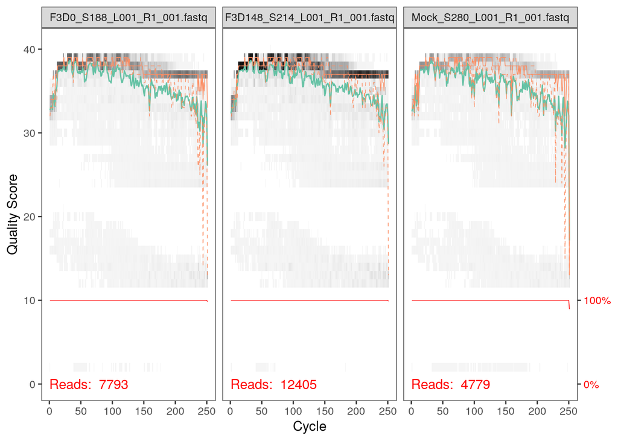

```r
plotQualityProfile(fnFs [c(1, 10, 20)])
```

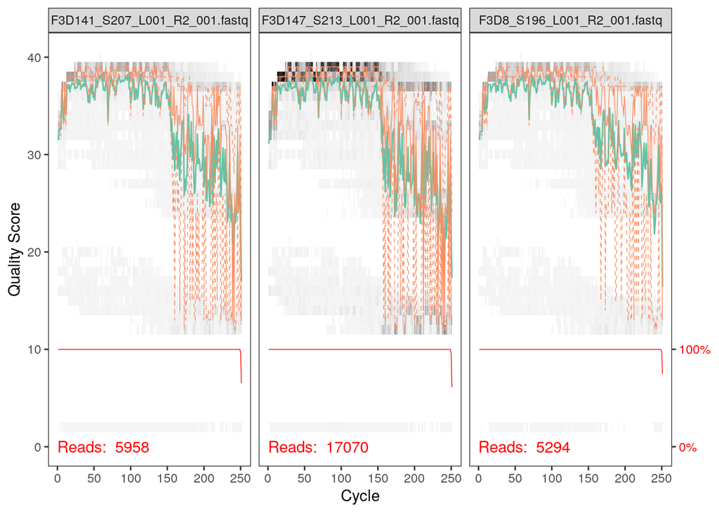

```r
plotQualityProfile(fnRs[c(3, 9, 18)])
```

## 3) FILTER AND TRIM

### Création d’un dossier filtered contenant les fichiers prêt pour filtration

file.path()–>créer un chemin de fichier path–>contient le dossier où se trouve les fichiers d’interet “filtered”–>ajoute un dossier “filtered” à ce chemin paste0()–>faire un collage entre le vecteur sample.names et le suffixe “_F_filt.fastq.gz” (sequences forwards) et “R_filt.fastq.gz” (séquences reverses).

```r
filtFs <- file.path(path, "filtered", paste0(sample.names, "_F_filt.fastq.gz"))
filtRs <- file.path(path, "filtered", paste0(sample.names, "_R_filt.fastq.gz"))
filtFs
```

```
##  [1] "/home/rstudio/DADA2_tutorial_ADM/MiSeq_SOP/filtered/F3D0_F_filt.fastq.gz"
##  [2] "/home/rstudio/DADA2_tutorial_ADM/MiSeq_SOP/filtered/F3D1_F_filt.fastq.gz"
##  [3] "/home/rstudio/DADA2_tutorial_ADM/MiSeq_SOP/filtered/F3D141_F_filt.fastq.gz"
##  [4] "/home/rstudio/DADA2_tutorial_ADM/MiSeq_SOP/filtered/F3D142_F_filt.fastq.gz"
##  [5] "/home/rstudio/DADA2_tutorial_ADM/MiSeq_SOP/filtered/F3D143_F_filt.fastq.gz"
##  [6] "/home/rstudio/DADA2_tutorial_ADM/MiSeq_SOP/filtered/F3D144_F_filt.fastq.gz"
##  [7] "/home/rstudio/DADA2_tutorial_ADM/MiSeq_SOP/filtered/F3D145_F_filt.fastq.gz"
##  [8] "/home/rstudio/DADA2_tutorial_ADM/MiSeq_SOP/filtered/F3D146_F_filt.fastq.gz"
##  [9] "/home/rstudio/DADA2_tutorial_ADM/MiSeq_SOP/filtered/F3D147_F_filt.fastq.gz"
## [10] "/home/rstudio/DADA2_tutorial_ADM/MiSeq_SOP/filtered/F3D148_F_filt.fastq.gz"
## [11] "/home/rstudio/DADA2_tutorial_ADM/MiSeq_SOP/filtered/F3D149_F_filt.fastq.gz"
## [12] "/home/rstudio/DADA2_tutorial_ADM/MiSeq_SOP/filtered/F3D150_F_filt.fastq.gz"
## [13] "/home/rstudio/DADA2_tutorial_ADM/MiSeq_SOP/filtered/F3D2_F_filt.fastq.gz"
## [14] "/home/rstudio/DADA2_tutorial_ADM/MiSeq_SOP/filtered/F3D3_F_filt.fastq.gz"
## [15] "/home/rstudio/DADA2_tutorial_ADM/MiSeq_SOP/filtered/F3D5_F_filt.fastq.gz"
## [16] "/home/rstudio/DADA2_tutorial_ADM/MiSeq_SOP/filtered/F3D6_F_filt.fastq.gz"
## [17] "/home/rstudio/DADA2_tutorial_ADM/MiSeq_SOP/filtered/F3D7_F_filt.fastq.gz"
## [18] "/home/rstudio/DADA2_tutorial_ADM/MiSeq_SOP/filtered/F3D8_F_filt.fastq.gz"
## [19] "/home/rstudio/DADA2_tutorial_ADM/MiSeq_SOP/filtered/F3D9_F_filt.fastq.gz"
## [20] "/home/rstudio/DADA2_tutorial_ADM/MiSeq_SOP/filtered/Mock_F_filt.fastq.gz"
```

```r
filtRs
```

```
##  [1] "/home/rstudio/DADA2_tutorial_ADM/MiSeq_SOP/filtered/F3D0_R_filt.fastq.gz"
##  [2] "/home/rstudio/DADA2_tutorial_ADM/MiSeq_SOP/filtered/F3D1_R_filt.fastq.gz"
##  [3] "/home/rstudio/DADA2_tutorial_ADM/MiSeq_SOP/filtered/F3D141_R_filt.fastq.gz"
##  [4] "/home/rstudio/DADA2_tutorial_ADM/MiSeq_SOP/filtered/F3D142_R_filt.fastq.gz"
##  [5] "/home/rstudio/DADA2_tutorial_ADM/MiSeq_SOP/filtered/F3D143_R_filt.fastq.gz"
##  [6] "/home/rstudio/DADA2_tutorial_ADM/MiSeq_SOP/filtered/F3D144_R_filt.fastq.gz"
##  [7] "/home/rstudio/DADA2_tutorial_ADM/MiSeq_SOP/filtered/F3D145_R_filt.fastq.gz"
##  [8] "/home/rstudio/DADA2_tutorial_ADM/MiSeq_SOP/filtered/F3D146_R_filt.fastq.gz"
##  [9] "/home/rstudio/DADA2_tutorial_ADM/MiSeq_SOP/filtered/F3D147_R_filt.fastq.gz"
## [10] "/home/rstudio/DADA2_tutorial_ADM/MiSeq_SOP/filtered/F3D148_R_filt.fastq.gz"
## [11] "/home/rstudio/DADA2_tutorial_ADM/MiSeq_SOP/filtered/F3D149_R_filt.fastq.gz"
## [12] "/home/rstudio/DADA2_tutorial_ADM/MiSeq_SOP/filtered/F3D150_R_filt.fastq.gz"
## [13] "/home/rstudio/DADA2_tutorial_ADM/MiSeq_SOP/filtered/F3D2_R_filt.fastq.gz"
## [14] "/home/rstudio/DADA2_tutorial_ADM/MiSeq_SOP/filtered/F3D3_R_filt.fastq.gz"
## [15] "/home/rstudio/DADA2_tutorial_ADM/MiSeq_SOP/filtered/F3D5_R_filt.fastq.gz"
## [16] "/home/rstudio/DADA2_tutorial_ADM/MiSeq_SOP/filtered/F3D6_R_filt.fastq.gz"
## [17] "/home/rstudio/DADA2_tutorial_ADM/MiSeq_SOP/filtered/F3D7_R_filt.fastq.gz"
## [18] "/home/rstudio/DADA2_tutorial_ADM/MiSeq_SOP/filtered/F3D8_R_filt.fastq.gz"
## [19] "/home/rstudio/DADA2_tutorial_ADM/MiSeq_SOP/filtered/F3D9_R_filt.fastq.gz"
## [20] "/home/rstudio/DADA2_tutorial_ADM/MiSeq_SOP/filtered/Mock_R_filt.fastq.gz"
```

### filtration et troncation

Ici, je viens stocker filtFs et filtRs, mes échantillons fnFs et fnRs une fois ceux-ci filtrés et tronqués par la fonction filterAndtrim(), puis je les mets dans un objet “out” comme ceci :

trunclen=c(240,160)–> seq tronquées après 240 (forward) et 160 (reverse) nucleotides maxN=0–> toute seq contenant au moins une base N (ambigue) sera éliminée. maxEE=c(2,2)–> max expected errors quality score 2 (forward et reverse) (phred score)–>https://en.wikipedia.org/wiki/Phred_quality_score truncQ=2–> seq tronquée dès que Phred score est de 2 rm.phix=TRUE–>les seq du phage PhiX sont supprimées, il est utilisé comme controle dans le sequencage (c’est une verification). compress=TRUE–> fichiers de sortie seront compressés en format gzip (fichier .gz) multithread=TRUE–>utilise plusieurs coeurs du processeur pour executer plus vite

```r
out <- filterAndTrim(fnFs, filtFs, fnRs, filtRs, truncLen=c(240,160),
              maxN=0, maxEE=c(2,2), truncQ=2, rm.phix=TRUE,
              compress=TRUE, multithread=TRUE)
head(out)
```

```
##                               reads.in reads.out
## F3D0_S188_L001_R1_001.fastq       7793      7113
## F3D1_S189_L001_R1_001.fastq       5869      5299
## F3D141_S207_L001_R1_001.fastq     5958      5463
## F3D142_S208_L001_R1_001.fastq     3183      2914
## F3D143_S209_L001_R1_001.fastq     3178      2941
## F3D144_S210_L001_R1_001.fastq     4827      4312
```

## 4) LEARN THE ERRORS RATES

### Modèle d’erreures

Lors du séquençage de l’ADN, il y a des erreurs aléatoires (mutations de nucléotides) qui peuvent se produire. Si on ne tient pas compte de ces erreurs, on risque de confondre des erreurs techniques avec de véritables variantes dans les séquences. DADA2 modélise ces erreurs pour corriger et identifier les séquences réelles présentes dans l’échantillon.

La fonction learnErrors ajuste un modèle statistique qui décrit la probabilité qu’un nucléotide soit incorrectement séquencé en fonction de la qualité de la base (souvent mesurée par un score de qualité Q, https://en.wikipedia.org/wiki/Phred_quality_score). Plus précisément, elle modélise la probabilité d’observer une séquence erronée étant donné les données de qualité associées à chaque base.

#### Détail du code

learnErrors()–>modélise les probabilités d’erreurs. plotErrors–>afficher les taux d’erreurs observé à partir des données réelles (POINTS NOIRS) le taux d’erreurs estimé par learnErrors()(LIGNE NOIRE) nominalQ=TRUE permet d’afficher le taux d’erreurs nominal de la plateforme dada2 sans apprentissage de mes données (LIGNE ROUGE)

```r
errF <- learnErrors(filtFs, multithread=TRUE)
```

```
## 33514080 total bases in 139642 reads from 20 samples will be used for learning the error rates.
```

```r
errR <- learnErrors(filtRs, multithread=TRUE)
```

```
## 22342720 total bases in 139642 reads from 20 samples will be used for learning the error rates.
```

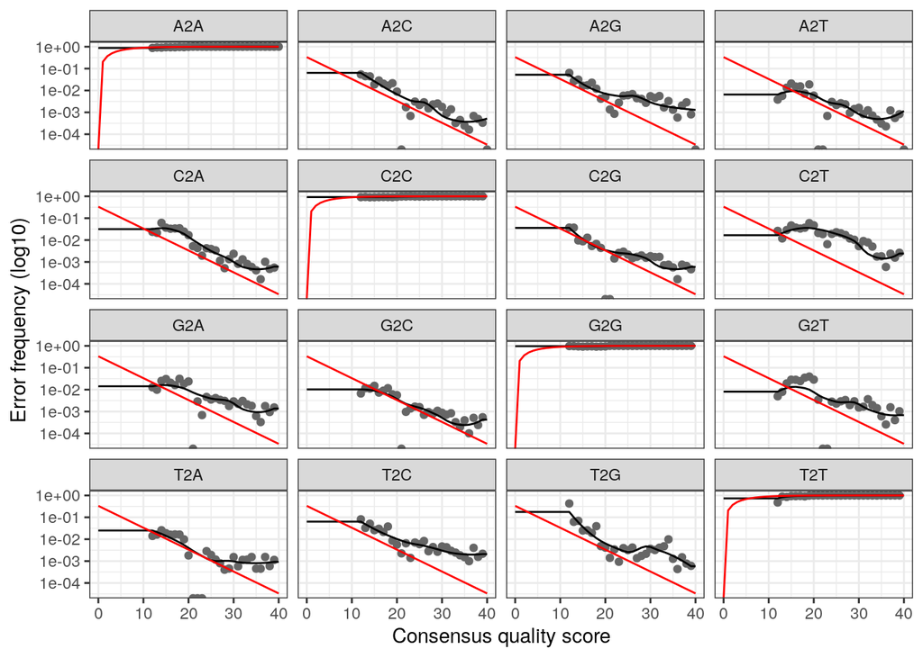

```r
plotErrors(errF, nominalQ=TRUE)
```

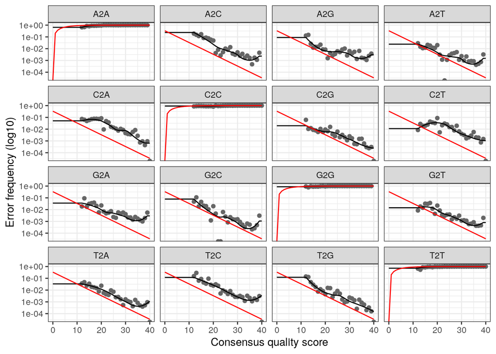

```r
plotErrors(errR, nominalQ=TRUE)
```

## 5) SAMPLE INFERENCE

Ici, j’applique l’algo dada à mes échantillons de bonnes qualités filtFs, avec err=errF indiquant que mon modèle d’erreur est errF. L’algorithme dada permet de differencier les differences de sequences dûent à des variations d’origine biologique ou à celles issue d’erreures de séquençage.

```r
dadaFs <- dada(filtFs, err=errF, multithread=TRUE)
```

```
## Sample 1 - 7113 reads in 1979 unique sequences.
## Sample 2 - 5299 reads in 1639 unique sequences.
## Sample 3 - 5463 reads in 1477 unique sequences.
## Sample 4 - 2914 reads in 904 unique sequences.
## Sample 5 - 2941 reads in 939 unique sequences.
## Sample 6 - 4312 reads in 1267 unique sequences.
## Sample 7 - 6741 reads in 1756 unique sequences.
## Sample 8 - 4560 reads in 1438 unique sequences.
## Sample 9 - 15637 reads in 3590 unique sequences.
## Sample 10 - 11413 reads in 2762 unique sequences.
## Sample 11 - 12017 reads in 3021 unique sequences.
## Sample 12 - 5032 reads in 1566 unique sequences.
## Sample 13 - 18075 reads in 3707 unique sequences.
## Sample 14 - 6250 reads in 1479 unique sequences.
## Sample 15 - 4052 reads in 1195 unique sequences.
## Sample 16 - 7369 reads in 1832 unique sequences.
## Sample 17 - 4765 reads in 1183 unique sequences.
## Sample 18 - 4871 reads in 1382 unique sequences.
## Sample 19 - 6504 reads in 1709 unique sequences.
## Sample 20 - 4314 reads in 897 unique sequences.
```

```r
dadaRs <- dada(filtRs, err=errR, multithread=TRUE)
```

```
## Sample 1 - 7113 reads in 1660 unique sequences.
## Sample 2 - 5299 reads in 1349 unique sequences.
## Sample 3 - 5463 reads in 1335 unique sequences.
## Sample 4 - 2914 reads in 853 unique sequences.
## Sample 5 - 2941 reads in 880 unique sequences.
## Sample 6 - 4312 reads in 1286 unique sequences.
## Sample 7 - 6741 reads in 1803 unique sequences.
## Sample 8 - 4560 reads in 1265 unique sequences.
## Sample 9 - 15637 reads in 3414 unique sequences.
## Sample 10 - 11413 reads in 2522 unique sequences.
## Sample 11 - 12017 reads in 2771 unique sequences.
## Sample 12 - 5032 reads in 1415 unique sequences.
## Sample 13 - 18075 reads in 3290 unique sequences.
## Sample 14 - 6250 reads in 1390 unique sequences.
## Sample 15 - 4052 reads in 1134 unique sequences.
## Sample 16 - 7369 reads in 1635 unique sequences.
## Sample 17 - 4765 reads in 1084 unique sequences.
## Sample 18 - 4871 reads in 1161 unique sequences.
## Sample 19 - 6504 reads in 1502 unique sequences.
## Sample 20 - 4314 reads in 732 unique sequences.
```

```r
dadaFs[[1]]
```

```
## dada-class: object describing DADA2 denoising results
## 128 sequence variants were inferred from 1979 input unique sequences.
## Key parameters: OMEGA_A = 1e-40, OMEGA_C = 1e-40, BAND_SIZE = 16
```

```r
?setDadaOpt
```

```r
help("dada-class")
```

## 6) MERGE PAIRED READS

#### détail du code

mergePairs()–> permet la fusion des forwards et reverses après le débruitage. il faut lui préciser dadaFs puis filtFs pour lui dire le chemin d’accès.

verbose=TRUE

Progrès des fusions : Le nombre de paires de séquences en cours de traitement est affiché pendant que DADA2 procède à la fusion. Cela permet de suivre la progression du processus.

Résumé des fusions : Des statistiques sur le nombre total de lectures appariées, ainsi que des détails sur les fusions réussies ou échouées, sont rapportées.

Informations sur les erreurs : Si des paires de séquences ne parviennent pas à fusionner, par exemple en raison d’un chevauchement insuffisant ou d’un trop grand nombre de mésappariements, ces informations seront également affichées.

```r
mergers <- mergePairs(dadaFs, filtFs, dadaRs, filtRs, verbose=TRUE)
```

```
## 6540 paired-reads (in 107 unique pairings) successfully merged out of 6891 (in 197 pairings) input.
```

```
## 5028 paired-reads (in 101 unique pairings) successfully merged out of 5190 (in 157 pairings) input.
```

```
## 4986 paired-reads (in 81 unique pairings) successfully merged out of 5267 (in 166 pairings) input.
```

```
## 2595 paired-reads (in 52 unique pairings) successfully merged out of 2754 (in 108 pairings) input.
```

```
## 2553 paired-reads (in 60 unique pairings) successfully merged out of 2785 (in 119 pairings) input.
```

```
## 3646 paired-reads (in 55 unique pairings) successfully merged out of 4109 (in 157 pairings) input.
```

```
## 6079 paired-reads (in 81 unique pairings) successfully merged out of 6514 (in 198 pairings) input.
```

```
## 3968 paired-reads (in 91 unique pairings) successfully merged out of 4388 (in 187 pairings) input.
```

```
## 14233 paired-reads (in 143 unique pairings) successfully merged out of 15355 (in 352 pairings) input.
```

```
## 10528 paired-reads (in 120 unique pairings) successfully merged out of 11165 (in 278 pairings) input.
```

```
## 11154 paired-reads (in 137 unique pairings) successfully merged out of 11797 (in 298 pairings) input.
```

```
## 4349 paired-reads (in 85 unique pairings) successfully merged out of 4802 (in 179 pairings) input.
```

```
## 17431 paired-reads (in 153 unique pairings) successfully merged out of 17812 (in 272 pairings) input.
```

```
## 5850 paired-reads (in 81 unique pairings) successfully merged out of 6095 (in 159 pairings) input.
```

```
## 3716 paired-reads (in 86 unique pairings) successfully merged out of 3894 (in 147 pairings) input.
```

```
## 6865 paired-reads (in 99 unique pairings) successfully merged out of 7191 (in 187 pairings) input.
```

```
## 4426 paired-reads (in 67 unique pairings) successfully merged out of 4603 (in 127 pairings) input.
```

```
## 4576 paired-reads (in 101 unique pairings) successfully merged out of 4739 (in 174 pairings) input.
```

```
## 6092 paired-reads (in 109 unique pairings) successfully merged out of 6315 (in 173 pairings) input.
```

```
## 4269 paired-reads (in 20 unique pairings) successfully merged out of 4281 (in 28 pairings) input.
```

```r
head(mergers[[1]])
```

```
##                                                                                                                                                                                                                                                       sequence
## 1 TACGGAGGATGCGAGCGTTATCCGGATTTATTGGGTTTAAAGGGTGCGCAGGCGGAAGAT…
## 2 TACGGAGGATGCGAGCGTTATCCGGATTTATTGGGTTTAAAGGGTGCGTAGGCGGCCTGC…
## 3 TACGGAGGATGCGAGCGTTATCCGGATTTATTGGGTTTAAAGGGTGCGTAGGCGGGCTGT…
## 4 TACGGAGGATGCGAGCGTTATCCGGATTTATTGGGTTTAAAGGGTGCGTAGGCGGGCTTT…
## 5 TACGGAGGATGCGAGCGTTATCCGGATTTATTGGGTTTAAAGGGTGCGCAGGCGGACTCT…
## 6 TACGGAGGATGCGAGCGTTATCCGGATTTATTGGGTTTAAAGGGTGCGTAGGCGGGATGC…
##   abundance forward reverse nmatch nmismatch nindel prefer accept
## 1       579       1       1    148         0      0      1   TRUE
## 2       470       2       2    148         0      0      2   TRUE
## 3       449       3       4    148         0      0      1   TRUE
## 4       430       4       3    148         0      0      2   TRUE
## 5       345       5       6    148         0      0      1   TRUE
## 6       282       6       5    148         0      0      2   TRUE
```

## 7) CONSTRUCT SEQUENCE TABLE

makeSequenceTable()–> Elle prend les résultats de la fusion des lectures (comme dans mergers) et produit une matrice dans laquelle : Chaque ligne correspond à un échantillon. Chaque colonne correspond à une séquence unique (ASV) identifiée après fusion. Les valeurs dans la matrice indiquent le nombre d’occurrences (abondance) de chaque séquence unique dans chaque échantillon.

```r
seqtab<-makeSequenceTable(mergers)
dim(seqtab)
```

```
## [1]  20 293
```

getSequences(seqtab) : Cette fonction extrait toutes les séquences uniques (les ASVs) de la table seqtab en tant que vecteur de chaînes de caractères. Chaque élément de ce vecteur correspond à une séquence unique détectée après débruitage et fusion des lectures.

nchar() : Calcule la longueur de chaque séquence dans le vecteur, c’est-à-dire le nombre de nucléotides dans chaque séquence.

table() : Crée une table de fréquence montrant combien de séquences ont une certaine longueur (nombre de nucléotides). Elle renvoie une table où : Chaque valeur correspond au nombre de séquences ayant une longueur donnée. Chaque nom de colonne correspond à une longueur spécifique.

```r
table(nchar(getSequences(seqtab)))
```

```
##
## 251 252 253 254 255
##   1  88 196   6   2
```

## 8) REMOVE CHIMERAS

removeBimeraDenovo() : Identifie et retire les séquences chimériques dans la table de séquences. Les chimères se forment lorsqu’un fragment d’ADN est mal répliqué pendant la PCR, donnant une séquence hybride entre deux séquences existantes, dûe à la partie conservée.

Arguments :

method=“consensus” : La méthode “consensus” compare chaque séquence à d’autres séquences plus abondantes. Une séquence est considérée comme chimérique si elle peut être formée par la combinaison de deux séquences parentales. verbose=TRUE : Affiche des informations supplémentaires sur le processus de suppression des chimères.

```r
seqtab.nochim <- removeBimeraDenovo(seqtab, method="consensus", multithread=TRUE, verbose=TRUE)
```

```
## Identified 61 bimeras out of 293 input sequences.
```

```r
dim(seqtab.nochim)
```

```
## [1]  20 232
```

Calcul de la proportion des séquences non chimériques par rapport au total des séquences

```r
sum(seqtab.nochim)/sum(seqtab)
```

```
## [1] 0.9640374
```

## 9) TRACK READS THROUGH THE PIPELINE

```r
getN <- function(x) sum(getUniques(x))
```

### Création d’une matrice track qui contient une colonne pour chaque étape du pipeline, chaque ligne est un echantillon.

cbind()–>combine des objets par colonne, prend plusieurs vecteurs ou matrices et les met côte à côte pour créer une nouvelle matrice avec le même nombre de lignes.

rowSums(seqtab.nochim)–>calcule la somme des séquences non chimériques pour chaque échantillon, donnant ainsi le nombre final de séquences de haute qualité.

rownames(track) <- sample.names –> attribue les noms des lignes à la matrice track en utilisant les noms des échantillons

```r
track <- cbind(out, sapply(dadaFs, getN), sapply(dadaRs, getN), sapply(mergers, getN), rowSums(seqtab.nochim))
colnames(track) <- c("input", "filtered", "denoisedF", "denoisedR", "merged", "nonchim")
rownames(track) <- sample.names
head(track)
```

```
##        input filtered denoisedF denoisedR merged nonchim
## F3D0    7793     7113      6976      6979   6540    6528
## F3D1    5869     5299      5227      5239   5028    5017
## F3D141  5958     5463      5331      5357   4986    4863
## F3D142  3183     2914      2799      2830   2595    2521
## F3D143  3178     2941      2822      2868   2553    2519
## F3D144  4827     4312      4151      4228   3646    3507
```

Une bonne portion des inputs ont passés les differentes étapes de filtration, ce qui veut dire que mes paramètres de tris ne sont pas trop strictes.

## 10) ASSIGN TAXONOMY

### assignTaxonomy()–>attribue une classification taxonomique à seqtab.nochim en se basant sur une base de données de référence, ici SILVA 132

```r
taxa <- assignTaxonomy(seqtab.nochim, "/home/rstudio/tutoDada2/silva_nr_v132_train_set.fa.gz", multithread=TRUE)
```

addSpecies()–>ajoute des noms d’espèces à une table de taxonomie

```r
taxa <- addSpecies(taxa, "/home/rstudio/tutoDada2/silva_species_assignment_v132.fa.gz")
```

taxa.print <- taxa–>crée une copie de taxa sous le nom taxa.print. Ainsi, les modifications apportées à taxa.print n’affecteront pas taxa.

rownames(taxa.print) <- NULL–>supprime les noms de ligne

```r
taxa.print <- taxa
rownames(taxa.print) <- NULL
head(taxa.print)
```

```
##      Kingdom    Phylum          Class         Order           Family
## [1,] "Bacteria" "Bacteroidetes" "Bacteroidia" "Bacteroidales" "Muribaculaceae"
## [2,] "Bacteria" "Bacteroidetes" "Bacteroidia" "Bacteroidales" "Muribaculaceae"
## [3,] "Bacteria" "Bacteroidetes" "Bacteroidia" "Bacteroidales" "Muribaculaceae"
## [4,] "Bacteria" "Bacteroidetes" "Bacteroidia" "Bacteroidales" "Muribaculaceae"
## [5,] "Bacteria" "Bacteroidetes" "Bacteroidia" "Bacteroidales" "Bacteroidaceae"
## [6,] "Bacteria" "Bacteroidetes" "Bacteroidia" "Bacteroidales" "Muribaculaceae"
##      Genus         Species
## [1,] NA            NA
## [2,] NA            NA
## [3,] NA            NA
## [4,] NA            NA
## [5,] "Bacteroides" NA
## [6,] NA            NA
```

## 11) EVALUATE ACCURACY

### Évaluation de la précision de DADA2 sur la communauté fictive

seqtab.nochim[“Mock”,]–>extrait les sequences associées à l’échantillon de reference Mock dans seqtab.nochim , indique que je prend toutes les colonnes (toutes les séquences associées à cet échantillon).

```r
unqs.mock <- seqtab.nochim["Mock_F_filt.fastq.gz",]
```

### Trie les séquences de l’échantillon “Mock” par ordre décroissant de leur abondance, après avoir filtré les séquences avec une abondance supérieure à zéro :

unqs.mock[unqs.mock > 0]–>sélectionne uniquement les séquences dont l’abondance>0, c’est-à-dire, les séquences réellement observées dans l’échantillon “Mock”.

sort(…, decreasing = TRUE)–>sort() trie les valeurs dans l’ordre croissant. En ajoutant decreasing = TRUE, les séquences sont triées par ordre décroissant, de l’abondance la plus élevée à la plus faible.

```r
unqs.mock <- sort(unqs.mock[unqs.mock>0], decreasing=TRUE)
```

cat()–>concaténer et afficher des éléments. Ici, elle affiche un message comprenant du texte et une valeur calculée.

length(unqs.mock–>renvoie le nombre d’éléments dans l’objet unqs.mock. Cela correspond au nombre de séquences uniques présentes dans l’échantillon “Mock”, après avoir appliqué le tri et la suppression des séquences avec une abondance de zéro.

```r
cat("DADA2 inferred", length(unqs.mock), "sample sequences present in the Mock community.\n")
```

```
## DADA2 inferred 20 sample sequences present in the Mock community.
```

### Extrait les séquences de référence à partir d’un fichier FASTA pour l’échantillon “Mock” et les stocke dans l’objet mock.ref

```r
mock.ref <- getSequences(file.path(path, "HMP_MOCK.v35.fasta"))
```

Comparer les séquences inférées dans l’échantillon “Mock” avec les séquences de référence et compter combien d’entre elles correspondent à celles présentes dans le fichier de référence (mock.ref)

```r
match.ref <- sum(sapply(names(unqs.mock), function(x) any(grepl(x, mock.ref))))
```

```r
cat("Of those,", match.ref, "were exact matches to the expected reference sequences.\n")
```

```
## Of those, 20 were exact matches to the expected reference sequences.
```

On a bien 20/20 en correspondance avec l’echantillon de reference mock, ce qui signifie qu’aucune erreure majeure dans le sequencage ni dans le pipeline dada2 n’est a declarer.